# Temperaturschwankungen im offenen Bohrloch B40

head04 (200 m, luftgefüllt, Ø 12 cm), Januar–August 2026, mit den 95-s-Daten von B46

Author

Thom Laepple

Published

October 1, 2026

**Hypothese.** Die Tag-zu-Tag-Schwankungen in B40 sind ein einziges druckgetriebenes Signal mit festem Tiefenprofil, `T′(z,t) = b(z)·F(t)`, mit `F` ≈ dp/dt. Das Profil `b(z)` hat zwei Bereiche: oberhalb des Close-off strömt Luft durch das Loch und trägt den Temperaturgradienten mit (Advektion); unterhalb erwärmt sich die Bohrlochluft adiabatisch bei Kompression und gibt die Wärme an die Wand ab (Kompressionswärme).

```r
library(dplyr); library(tidyr); library(ggplot2); library(patchwork)
BLUE <- "#2a78d6"; ORANGE <- "#eb6834"; GREY <- "grey45"
th <- theme_bw(base_size = 12) + theme(panel.grid.minor = element_blank())
K   <- "data/"
B46 <- "/Users/tlaepple/Nextcloud/KohnenRecords2526/2026_01_05/260105_B46/calibrated/CalibratedData_B46_2chains_260105.csv"
tp  <- function(x) as.POSIXct(x, format = "%Y-%m-%dT%H:%M:%SZ", tz = "UTC")

h4 <- read.csv(paste0(K, "decoded_head04_231710_combined.csv")); h4$t <- tp(h4$time_utc)
h3 <- read.csv(paste0(K, "decoded_head03_231709_combined.csv")); h3$t <- tp(h3$time_utc)
d03 <- read.csv(paste0(K, "head03_depths.csv"))
c4  <- unique(read.csv(paste0(K, "head04_calibration.csv"))[, c("node", "depth_m")])
c4  <- c4[c4$node <= 20, ]

# Druckreferenz: Netzmittel B50 (head03, 09 und 21 UTC), Sensoren nie unter −45 °C
P3  <- sapply(d03$node, function(n) h3[[sprintf("n%d.pressure_hPa", n)]])
Tm3 <- sapply(d03$node, function(n) min(h3[[sprintf("n%d.ntc1_temp_C", n)]], na.rm = TRUE))
o3  <- order(h3$t); t3 <- as.numeric(h3$t[o3]); p3 <- rowMeans(P3[, Tm3 > -45], na.rm = TRUE)[o3]
t3  <- t3[is.finite(p3)]; p3 <- p3[is.finite(p3)]

# auf die head04-Messzeit (17:38 UTC) interpoliert
h4 <- h4[order(h4$t), ]; tt <- as.numeric(h4$t)
h4$p    <- approx(t3, p3, tt)$y
h4$dpdt <- approx(t3[-1] - diff(t3)/2, diff(p3)/diff(t3) * 86400, tt)$y   # hPa/Tag
h4 <- h4[is.finite(h4$p) & is.finite(h4$dpdt), ]
td <- (as.numeric(h4$t) - as.numeric(h4$t[1])) / 86400

prof <- sapply(c4$node, function(n) mean(h4[[sprintf("n%d.ntc1_temp_C", n)]], na.rm = TRUE))
gfun <- splinefun(c4$depth_m, prof, method = "natural")
```

## Befund: ein Antrieb, alle Tiefen

Je Tiefe wird die Temperatur hochpassgefiltert (loess-Residuum, span 0,2) und auf das ebenso gefilterte Drucksignal und auf dp/dt regressiert. Grundlage: 180 Tagesprofile, 18.01.–21.07.2026.

```r
rp <- resid(loess(h4$p ~ td, span = 0.2))
sel <- which(c4$depth_m >= 21)
R <- NULL; Rb <- NULL
tab <- bind_rows(lapply(sel, function(i) {
  n <- c4$node[i]; y <- h4[[sprintf("n%d.ntc1_temp_C", n)]] * 1000
  y2 <- h4[[sprintf("n%d.ntc2_temp_C", n)]] * 1000
  r <- y - predict(loess(y ~ td, span = 0.2), data.frame(td = td))
  f <- lm(r ~ rp + h4$dpdt); s <- summary(f)$coefficients
  rr <- rep(NA_real_, length(r)); rr[as.integer(names(resid(f)))] <- resid(f)
  R <<- cbind(R, rr); Rb <<- cbind(Rb, r)
  data.frame(z = c4$depth_m[i], grad = gfun(c4$depth_m[i], 1) * 1000,
             sd_r = sd(r, na.rm = TRUE), b = s[3, 1], t = s[3, 3],
             r2 = summary(f)$r.squared, sd_f = sd(resid(f)),
             repl = sd(diff(y - y2), na.rm = TRUE) / sqrt(2)) }))
colnames(R) <- colnames(Rb) <- round(tab$z)

# Rest bei 26–50 m, normiert mit b, als zusätzliche Antriebsreihe (hPa/Tag)
ref <- round(tab$z) %in% c(26, 32, 40, 50)
up  <- rowMeans(sweep(R[, ref], 2, tab$b[ref], "/"))
tab$b_rest  <- sapply(seq_len(ncol(R)), function(j) coef(lm(R[, j] ~ up))[2])
tab$r_rest  <- sapply(seq_len(ncol(R)), function(j) cor(R[, j], up, use = "c"))
tab$sd_rang1 <- apply(R - outer(up, tab$b), 2, sd, na.rm = TRUE)

knitr::kable(tab |> transmute(`Tiefe (m)` = round(z), `dT/dz (mK/m)` = round(grad, 1),
    `b (mK je hPa/Tag)` = signif(b, 3), t = round(t, 1), `R²` = round(r2, 2),
    `Streuung (mK)` = signif(sd_r, 3), `nach dp/dt` = signif(sd_f, 3),
    `Rest gegen Rest 26–50 m` = signif(b_rest, 3), r = round(r_rest, 2),
    `nach b·F` = signif(sd_rang1, 2), `Replikat` = signif(repl, 2)), row.names = FALSE,
  caption = "head04. b: Koeffizient von dp/dt. „Rest gegen Rest“: Steigung des Residuums gegen das mit b normierte Residuum bei 26–50 m. „nach b·F“: Streuung nach Abzug von b·(dp/dt + Rest).")
```

head04. b: Koeffizient von dp/dt. „Rest gegen Rest“: Steigung des Residuums gegen das mit b normierte Residuum bei 26–50 m. „nach b·F“: Streuung nach Abzug von b·(dp/dt + Rest).

| Tiefe (m) | dT/dz (mK/m) | b (mK je hPa/Tag) | t | R² | Streuung (mK) | nach dp/dt | Rest gegen Rest 26–50 m | r | nach b·F | Replikat |
| --- | --- | --- | --- | --- | --- | --- | --- | --- | --- | --- |
| 21 | -28.5 | 6.8900 | 27.8 | 0.81 | 42.600 | 18.4000 | 7.0900 | 0.97 | 4.600 | 0.130 |
| 26 | -18.6 | 2.5600 | 29.7 | 0.84 | 15.700 | 6.3700 | 2.5300 | 1.00 | 0.610 | 0.052 |
| 32 | -11.0 | 2.3000 | 28.5 | 0.82 | 14.200 | 5.9700 | 2.3400 | 0.98 | 1.200 | 0.058 |
| 40 | -5.7 | 0.6540 | 27.7 | 0.82 | 4.090 | 1.7500 | 0.6920 | 0.99 | 0.240 | 0.044 |
| 50 | -4.5 | 0.5320 | 31.2 | 0.85 | 3.260 | 1.2600 | 0.4980 | 0.99 | 0.210 | 0.043 |
| 62 | -2.8 | 0.1510 | 27.8 | 0.82 | 0.956 | 0.4020 | 0.1520 | 0.95 | 0.130 | 0.037 |
| 75 | 0.3 | 0.0885 | 36.9 | 0.90 | 0.551 | 0.1780 | 0.0647 | 0.91 | 0.094 | 0.046 |
| 92 | 1.2 | 0.0207 | 29.0 | 0.84 | 0.131 | 0.0529 | 0.0175 | 0.83 | 0.031 | 0.042 |
| 111 | 2.5 | 0.0192 | 27.5 | 0.81 | 0.120 | 0.0517 | 0.0166 | 0.80 | 0.031 | 0.045 |
| 134 | 3.2 | 0.0159 | 25.7 | 0.79 | 0.100 | 0.0457 | 0.0139 | 0.76 | 0.030 | 0.041 |
| 158 | 4.7 | 0.0195 | 24.8 | 0.78 | 0.124 | 0.0580 | 0.0194 | 0.84 | 0.032 | 0.043 |
| 187 | 4.2 | 0.0260 | 30.3 | 0.84 | 0.160 | 0.0636 | 0.0207 | 0.81 | 0.039 | 0.049 |
| 201 | 3.1 | 0.0122 | 18.9 | 0.68 | 0.085 | 0.0480 | 0.0116 | 0.60 | 0.038 | 0.047 |

- dp/dt erklärt in jeder Tiefe 68–90 % der Varianz (t = 19–37). Der phasengleiche Druckanteil ist daneben klein.
- Der Rest ist über die ganze Säule korreliert, und seine Steigung gegen den Rest bei 26–50 m ist in jeder Tiefe gleich `b` (Spalte „Rest gegen Rest“). Er hat also dasselbe Tiefenprofil wie das Drucksignal. Ein Gleichtakt der Elektronik hätte in allen Tiefen dieselbe Amplitude in mK; mit dem Residuum der Platinentemperatur korreliert er bei 111 und 158 m mit r = 0,14 bzw. 0,17.
- Mit der Kette selbst als Referenz (`F = dp/dt + Rest`) sinkt die Streuung bei 92–201 m auf 0,03–0,04 mK, das Niveau des Replikatrauschens. Diese Tiefen gehen in die Bestimmung von `F` nicht ein.

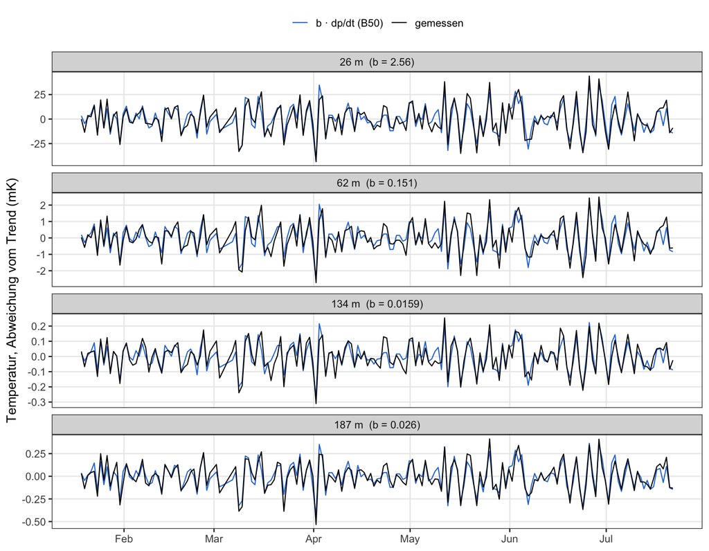

Figure 1

```r
zs <- c(26, 62, 134, 187)
ts_df <- bind_rows(lapply(zs, function(z) { j <- which(round(tab$z) == z)
  data.frame(t = h4$t, z = z, gemessen = Rb[, j], `b · dp/dt (B50)` = tab$b[j] * h4$dpdt,
             check.names = FALSE) })) |>
  pivot_longer(c(gemessen, `b · dp/dt (B50)`)) |>
  mutate(zl = factor(sprintf("%d m  (b = %.3g)", z, tab$b[match(z, round(tab$z))]),
                     sprintf("%d m  (b = %.3g)", zs, tab$b[match(zs, round(tab$z))])))
ggplot(ts_df, aes(t, value, colour = name)) + geom_line(linewidth = 0.45) +
  facet_wrap(~ zl, ncol = 1, scales = "free_y") +
  scale_colour_manual(values = c(gemessen = "black", `b · dp/dt (B50)` = BLUE), name = NULL) +
  labs(x = NULL, y = "Temperatur, Abweichung vom Trend (mK)") + th + theme(legend.position = "top")
```

Abbildung 1: Hochpassgefilterte Temperatur in vier Tiefen über und unter dem Close-off, dazu `b·dp/dt` mit dem Druck von B50. Die Amplitude unterscheidet sich zwischen 26 und 187 m um den Faktor 100, der Zeitverlauf ist derselbe.

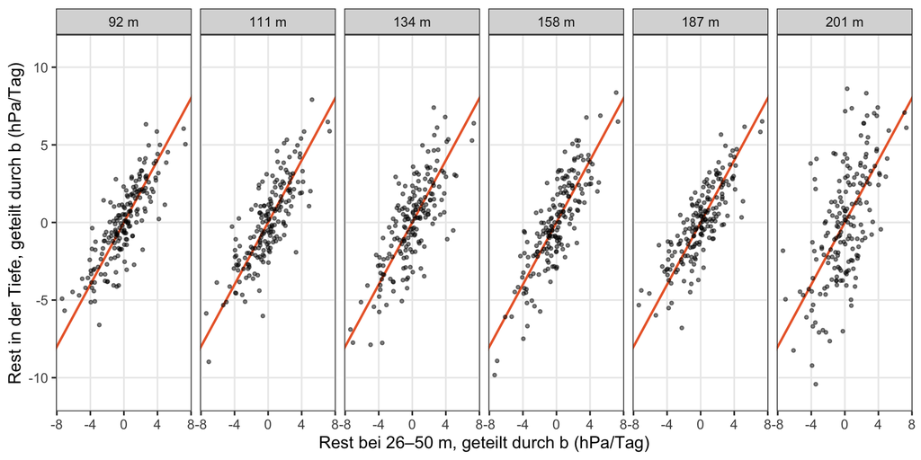

Figure 2

```r
deepz <- round(tab$z)[tab$z >= 90]
rest_df <- bind_rows(lapply(deepz, function(z) { j <- which(round(tab$z) == z)
  data.frame(z = factor(z), up = up, y = R[, j] / tab$b[j]) }))
lim <- range(up, na.rm = TRUE)
ggplot(rest_df, aes(up, y)) +
  geom_abline(slope = 1, intercept = 0, colour = ORANGE, linewidth = 0.8) +
  geom_point(size = 0.9, alpha = 0.5) + facet_wrap(~ z, nrow = 1, labeller = as_labeller(function(x) paste(x, "m"))) +
  coord_cartesian(xlim = lim, ylim = 1.5 * lim) +
  labs(x = "Rest bei 26–50 m, geteilt durch b (hPa/Tag)",
       y = "Rest in der Tiefe, geteilt durch b (hPa/Tag)") + th
```

Abbildung 2: Der Teil, den dp/dt von B50 nicht erklärt, in 92–201 m gegen denselben Rest bei 26–50 m, jeweils durch das eigene `b` geteilt. Die orange Linie ist die 1:1-Gerade, die bei einem gemeinsamen Antrieb gilt. Die tiefen Knoten gehen in die Referenz nicht ein.

```r
cat(sprintf("sd dp/dt (B50) = %.1f hPa/Tag, sd Zusatzanteil = %.1f hPa/Tag, Korrelation %.2f",
            sd(h4$dpdt), sd(up, na.rm = TRUE), cor(h4$dpdt, up, use = "c")))
```

```
sd dp/dt (B50) = 5.6 hPa/Tag, sd Zusatzanteil = 2.5 hPa/Tag, Korrelation -0.00
```

Der Zusatzanteil ist mit dem B50-dp/dt unkorreliert. Die wahrscheinliche Quelle ist die Druckänderung, die eine Referenz mit zwei Werten am Tag nicht auflöst (Abschnitt B46 unten); Wind ist nicht ausgeschlossen.

**Zeitauflösung von dp/dt.** Die Temperatur ist eine Punktmessung um 17:38 UTC. dp/dt ist die Steigung zwischen zwei B50-Werten (09:03 und 21:03 UTC), der Intervallmitte zugeordnet und auf 17:38 interpoliert: 79 % Gewicht auf 09:03→21:03, 21 % auf 21:03→09:03 des Folgetags. Die Temperatur antwortet aber auf die Druckänderung der letzten Minuten bis Viertelstunde (τ, siehe unten). Die 12-h-Steigung steht also für diese Rate; der erklärte Anteil ist eine Untergrenze, und `b` kann durch die Ersatzgröße verzerrt sein.

## Oberhalb des Close-off: Advektion

Bis 75 m nimmt die Temperatur im Loch nach unten ab, und `b` ist positiv: steigt der Druck, strömt Luft nach unten und bringt wärmere Luft von oben. Den Zeitverlauf zeigen erst die 95-s-Daten von B46 (02.–05.01.2026, 60-m-Kette im noch offenen Loch, Druck und NTC an jedem Knoten).

```r
d46 <- tryCatch(read.csv(B46), error = function(e) NULL)
ok46 <- !is.null(d46)
if (ok46) {
  d46$t <- as.POSIXct(d46$DateTime, tz = "UTC")
  ts <- as.numeric(d46$t - d46$t[1], units = "secs")
  dm <- read.csv(paste0(K, "head02_depths.csv")); dm60 <- dm[dm$chain == "60m-Kette", ]
  hp <- function(x, tau) { y <- numeric(length(x)); lp <- x[1]
    for (i in seq_along(x)) { if (i > 1) lp <- lp + (1 - exp(-(ts[i] - ts[i-1]) / tau)) * (x[i] - lp)
                              y[i] <- x[i] - lp }; y }
  pr46 <- sapply(dm60$node, function(n) mean(d46[[paste0(n, "_NTC1")]]))
  g46  <- splinefun(dm60$depth_m, pr46, method = "natural")
  taus <- exp(seq(log(60), log(6 * 3600), length.out = 40)); tr <- poly(ts, 3)
  fit46 <- bind_rows(lapply(which(dm60$depth_m >= 16), function(i) {
    n <- dm60$node[i]; T <- d46[[paste0(n, "_NTC1")]] * 1000; p <- d46[[paste0(n, "_Pressure")]] / 1000
    rss <- sapply(taus, function(tau) sum(resid(lm(T ~ tr + hp(p, tau)))^2))
    tau <- taus[which.min(rss)]; f <- lm(T ~ tr + hp(p, tau))
    z <- dm60$depth_m[i]; G <- unname(coef(f)[5])
    data.frame(z = z, tau = tau / 60, G = G, Gcol = -g46(z, 1) * 1000 * z / mean(p),
               sd0 = sd(resid(lm(T ~ tr))), sd1 = sd(resid(f))) }))
  knitr::kable(fit46 |> transmute(`Tiefe (m)` = z, `τ (min)` = round(tau, 1),
      `G (mK/hPa)` = round(G, 1), `G / Säulenkompression` = round(G / Gcol),
      `Streuung vorher (mK)` = round(sd0, 2), `nachher` = round(sd1, 2)), row.names = FALSE,
    caption = "B46, offenes Loch: T = G·(p − Tiefpass_τ(p)) + Trend, mit dem Drucksensor desselben Knotens. Säulenkompression: G = −(dT/dz)·z/p.")
}
```

B46, offenes Loch: T = G·(p − Tiefpass_τ(p)) + Trend, mit dem Drucksensor desselben Knotens. Säulenkompression: G = −(dT/dz)·z/p.

| Tiefe (m) | τ (min) | G (mK/hPa) | G / Säulenkompression | Streuung vorher (mK) | nachher |
| --- | --- | --- | --- | --- | --- |
| 16 | 15.1 | 369.3 | 340 | 14.51 | 5.08 |
| 21 | 13.0 | 171.8 | 172 | 5.61 | 1.75 |
| 26 | 13.0 | 159.6 | 255 | 5.00 | 1.38 |
| 32 | 15.1 | 34.3 | 77 | 1.20 | 0.38 |
| 40 | 13.0 | 18.1 | 49 | 0.59 | 0.21 |
| 50 | 11.2 | 30.8 | 101 | 0.90 | 0.25 |
| 62 | 9.6 | 6.9 | 25 | 0.19 | 0.08 |

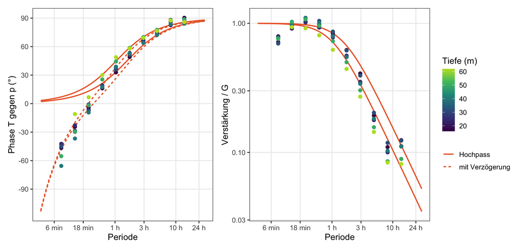

Figure 3

```r
if (ok46) {
  dtg <- 95; tg <- seq(0, max(ts), by = dtg); ip <- function(y) approx(ts, y, tg)$y
  edges <- exp(seq(log(0.06), log(30), length.out = 13))     # Periodengrenzen in h
  sp <- bind_rows(lapply(which(dm60$depth_m >= 16), function(i) {
    n <- dm60$node[i]
    X <- cbind(ip(d46[[paste0(n, "_Pressure")]] / 1000), ip(d46[[paste0(n, "_NTC1")]] * 1000))
    X <- apply(X, 2, function(x) resid(lm(x ~ poly(tg, 3))))
    s <- spec.pgram(ts(X, deltat = dtg / 3600), taper = 0.1, plot = FALSE)
    bind_rows(lapply(seq_len(length(edges) - 1), function(k) {
      j <- which(1 / s$freq > edges[k] & 1 / s$freq <= edges[k + 1]); if (length(j) < 2) return(NULL)
      Sxy <- sum(sqrt(s$coh[j] * s$spec[j, 1] * s$spec[j, 2]) * exp(1i * s$phase[j]))
      H <- Conj(Sxy) / sum(s$spec[j, 1])
      data.frame(z = dm60$depth_m[i], per = sqrt(edges[k] * edges[k + 1]),
                 coh = Mod(Sxy)^2 / (sum(s$spec[j, 1]) * sum(s$spec[j, 2])),
                 phase = Arg(H) * 180 / pi,
                 gain = Mod(H) / fit46$G[fit46$z == dm60$depth_m[i]]) })) }))
  pm <- expand.grid(per = exp(seq(log(0.06), log(30), length.out = 200)), tau = c(10, 15)) |>
    mutate(w = 2 * pi / (per * 60), phase = atan(1 / (w * tau)) * 180 / pi,
           gain = w * tau / sqrt(1 + (w * tau)^2), lab = sprintf("τ = %d min", tau))
  sp <- sp |> filter(coh > 0.5)
  # feste Verzögerung zwischen T und p eines Knotens (Abfragezeit oder Sensorantwort), τ = 13 min
  dly <- optimize(function(D) with(sp, sum((phase - (atan(1 / (2*pi/(per*3600) * 780)) -
                                   2*pi/(per*3600) * D) * 180/pi)^2)), c(0, 300))$minimum
  pm <- bind_rows(pm |> mutate(typ = "Hochpass"),
                  pm |> mutate(phase = phase - w / 60 * dly * 180 / pi, typ = "mit Verzögerung"))
  base <- list(scale_x_log10(breaks = c(0.1, 0.3, 1, 3, 10, 24), labels = c("6 min", "18 min", "1 h", "3 h", "10 h", "24 h")),
               scale_colour_viridis_c(name = "Tiefe (m)", end = 0.9), th, labs(x = "Periode"))
  p1 <- ggplot(sp, aes(per, phase)) +
    geom_line(aes(group = interaction(lab, typ), linetype = typ), data = pm, colour = ORANGE, linewidth = 0.8) +
    geom_point(aes(colour = z), size = 2) + base +
    scale_linetype_manual(values = c(Hochpass = "solid", `mit Verzögerung` = "22"), name = NULL) +
    scale_y_continuous(breaks = seq(-90, 90, 30)) + labs(y = "Phase T gegen p (°)")
  p2 <- ggplot(sp, aes(per, gain)) + geom_line(aes(group = lab), data = pm |> filter(typ == "Hochpass"), colour = ORANGE, linewidth = 0.8) +
    geom_point(aes(colour = z), size = 2) + base + scale_y_log10() + labs(y = "Verstärkung / G")
  p1 + p2 + plot_layout(guides = "collect")
}
```

Abbildung 4: B46, offenes Loch, Übertragungsfunktion vom Druck auf die Temperatur bei 16–62 m (Bänder mit Kohärenz über 0,5). Orange durchgezogen: Hochpass erster Ordnung mit τ = 10 und 15 min. 90° bedeutet T ∝ dp/dt, 0° bedeutet T ∝ p. Unterhalb von 20 min fällt die Phase weiter ab; das entspricht einer festen Verzögerung von 69 s zwischen Druck- und Temperaturwert desselben Knotens (gestrichelt), knapp ein Messintervall (95 s). Ob sie aus der Abfragereihenfolge oder aus der Sensorantwort stammt, ist offen; auf τ hat sie keinen Einfluss. Die Verstärkung ist durch das angepasste `G` der jeweiligen Tiefe geteilt.

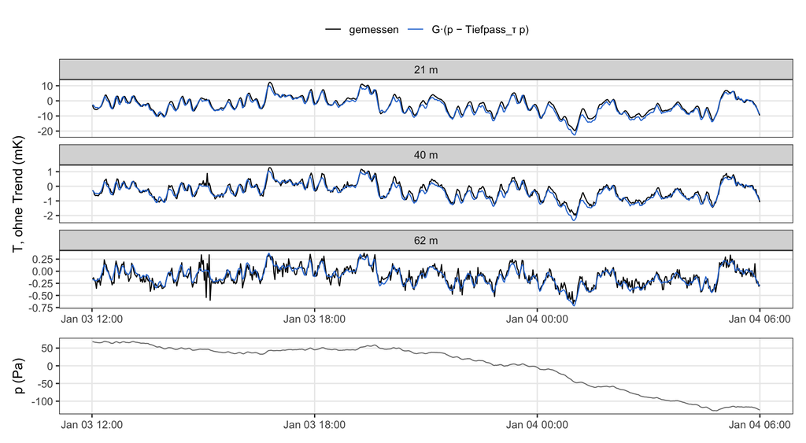

Figure 4

```r
if (ok46) {
  zsel <- c(21, 40, 62); win <- d46$t >= as.POSIXct("2026-01-03 12:00", tz = "UTC") &
                                d46$t <  as.POSIXct("2026-01-04 06:00", tz = "UTC")
  zm <- bind_rows(lapply(zsel, function(z) { n <- dm60$node[dm60$depth_m == z]
    T <- d46[[paste0(n, "_NTC1")]] * 1000; p <- d46[[paste0(n, "_Pressure")]] / 1000
    f <- fit46[fit46$z == z, ]; h <- hp(p, f$tau * 60)
    fl <- lm(T ~ tr + h); mod <- f$G * h; obs <- T - (fitted(fl) - coef(fl)["h"] * h)
    data.frame(t = d46$t, z = z, gemessen = obs, Modell = mod)[win, ] })) |>
    pivot_longer(c(gemessen, Modell)) |> mutate(zl = factor(sprintf("%d m", z), sprintf("%d m", zsel)))
  pz <- data.frame(t = d46$t, p = d46$N11_Pressure / 10)[win, ]
  g0 <- ggplot(pz, aes(t, p - mean(p))) + geom_line(colour = GREY, linewidth = 0.4) +
    labs(x = NULL, y = "p (Pa)") + th
  g1 <- ggplot(zm, aes(t, value, colour = name)) + geom_line(linewidth = 0.45) +
    facet_wrap(~ zl, ncol = 1, scales = "free_y") +
    scale_colour_manual(values = c(gemessen = "black", Modell = BLUE), name = NULL,
                        labels = c(gemessen = "gemessen", Modell = "G·(p − Tiefpass_τ p)")) +
    labs(x = NULL, y = "T, ohne Trend (mK)") + th + theme(legend.position = "top")
  g1 / g0 + plot_layout(heights = c(3, 1))
}
```

Abbildung 5: 18 Stunden aus B46, 95-s-Abtastung. Oben die Temperatur in drei Tiefen mit dem angepassten Hochpassmodell, unten der Druck am 40-m-Knoten (Abweichung vom Mittel).

```r
if (ok46) {
  pn <- paste0(dm$node[dm$chain == "10m-Kette"], "_Pressure")
  pb <- rowMeans(as.matrix(d46[, pn])) / 1000; s <- hp(pb, 780)
  r2 <- sapply(0:7, function(ph) { tk <- seq(ph * 5400, max(ts), by = 43200); pk <- approx(ts, pb, tk)$y
    ok <- ts > min(tk) & ts < max(tk)
    cor(s[ok], approx(tk[-1] - 21600, diff(pk) / 43200, ts[ok], rule = 2)$y)^2 })
  cat(sprintf("Anteil der Varianz von p − Tiefpass_13min(p), den eine 12-h-Referenz erfasst: %.0f %%", 100 * mean(r2)))
}
```

```
Anteil der Varianz von p − Tiefpass_13min(p), den eine 12-h-Referenz erfasst: 52 %
```

Eine Druckreferenz mit zwei Werten am Tag erfasst in diesen drei ruhigen Januartagen etwa die Hälfte des relevanten Signals; in B40 mit den größeren Winteränderungen sind es 68–90 %. Der Rest aus dem ersten Abschnitt liegt in dieser Größenordnung.

## Unterhalb des Close-off: Kompressionswärme der Bohrlochluft

Bei 92–201 m liegt `b` bei 0,012–0,026 mK je hPa/Tag, ohne Trend mit der Tiefe, und ist **positiv, obwohl der Gradient dort umgekehrt ist** (Temperatur steigt nach unten, +1,2 bis +4,7 mK/m). Advektion würde dort ein negatives `b` verlangen.

Die Luft im Loch erwärmt sich bei Kompression adiabatisch um `(R/c_p)·T/p` je hPa und gibt die Wärme an die Wand ab. Ändert sich der Druck langsam gegen die Wärmeleitzeit, stellt sich im Zylinder ein stationäres Profil ein; die Erwärmung beträgt auf der Achse `(R/c_p)(T/p)·(a²/4κ)·dp/dt`, im Querschnittsmittel die Hälfte davon.

**Warum dp/dt und nicht p.** Im verfüllten Loch folgt die Kompressionswärme dem Druck (`b = φ/(ρc)` ≈ 0,03 mK/hPa, `druck_temperatur.qmd`): die Porenluft gibt ihre Wärme in Millisekunden an die Eismatrix ab, die Matrix behält sie, und der Sensor misst die Matrix — die gespeicherte Wärme, proportional zu p. Im offenen Loch misst der Sensor die Luft. Sie gibt ihre Wärme in ~46 s an die Wand ab, deren Temperatur sich dabei nicht messbar ändert (die Luft trägt ~5·10⁻⁴ der Wärmekapazität). Der Überschuss der Luft gegenüber der Wand stellt sich auf das Gleichgewicht von Erwärmungsrate und Wärmeabfluss ein und ist damit proportional zu dp/dt. Derselbe Vorgang, zwei Beobachter: der Sensor im Firn sieht den Speicher, der Sensor in der Luft den Durchfluss.

```r
a <- 0.06; Tk <- 228.65; p <- 688; k_air <- 0.0206; rho <- p * 100 / (287.05 * Tk)
kap <- k_air / (rho * 1004); dTdp <- 0.2857 * Tk / p          # K/hPa
b_achse  <- dTdp * a^2 / (4 * kap) / 86400 * 1000              # mK je hPa/Tag
b_mittel <- b_achse / 2
deep <- tab |> filter(z >= 90)
knitr::kable(data.frame(
  Größe = c("adiabatische Erwärmung der Luft", "Temperaturleitfähigkeit Luft (−44,5 °C, 688 hPa)",
            "a²/(4κ) bei a = 6 cm", "b auf der Bohrlochachse", "b im Querschnittsmittel",
            "b gemessen, 92–201 m"),
  Wert = c(sprintf("%.3f K/hPa", dTdp), sprintf("%.2e m²/s", kap), sprintf("%.0f s", a^2/(4*kap)),
           sprintf("%.3f mK je hPa/Tag", b_achse), sprintf("%.3f mK je hPa/Tag", b_mittel),
           sprintf("%.3f–%.3f (Mittel %.3f)", min(deep$b), max(deep$b), mean(deep$b)))),
  row.names = FALSE, caption = "Kompressionswärme, ohne angepassten Parameter.")
```

Kompressionswärme, ohne angepassten Parameter.

| Größe | Wert |
| --- | --- |
| adiabatische Erwärmung der Luft | 0.095 K/hPa |
| Temperaturleitfähigkeit Luft (−44,5 °C, 688 hPa) | 1.96e-05 m²/s |
| a²/(4κ) bei a = 6 cm | 46 s |
| b auf der Bohrlochachse | 0.051 mK je hPa/Tag |
| b im Querschnittsmittel | 0.025 mK je hPa/Tag |
| b gemessen, 92–201 m | 0.012–0.026 (Mittel 0.019) |

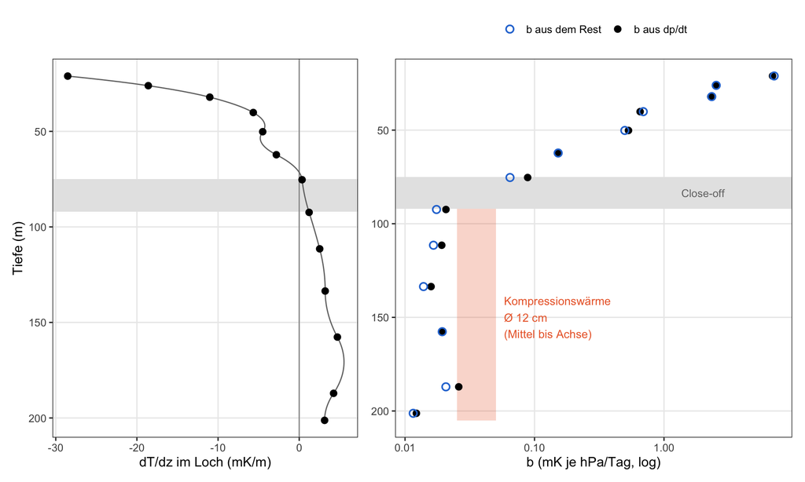

Figure 5

```r
zz <- seq(21, 201, by = 1)
g1 <- ggplot() + annotate("rect", ymin = 75, ymax = 92, xmin = -Inf, xmax = Inf, fill = "grey90") +
  geom_vline(xintercept = 0, colour = "grey60") +
  geom_path(aes(gfun(zz, 1) * 1000, zz), colour = GREY) +
  geom_point(aes(grad, z), data = tab, size = 2.5) +
  scale_y_reverse() + labs(x = "dT/dz im Loch (mK/m)", y = "Tiefe (m)") + th
g2 <- ggplot(tab) + annotate("rect", ymin = 75, ymax = 92, xmin = 0, xmax = Inf, fill = "grey90") +
  annotate("rect", xmin = b_mittel, xmax = b_achse, ymin = 92, ymax = 205, fill = ORANGE, alpha = 0.25) +
  annotate("text", x = b_achse * 1.15, y = 150, hjust = 0, size = 3.6, colour = ORANGE,
           label = "Kompressionswärme\nØ 12 cm\n(Mittel bis Achse)") +
  annotate("text", x = 2, y = 83.5, size = 3.4, colour = GREY, label = "Close-off") +
  geom_point(aes(b, z, colour = "b aus dp/dt"), size = 2.5) +
  geom_point(aes(b_rest, z, colour = "b aus dem Rest"), size = 2.5, shape = 1, stroke = 1) +
  scale_x_log10() + scale_y_reverse() +
  scale_colour_manual(values = c("b aus dp/dt" = "black", "b aus dem Rest" = BLUE), name = NULL) +
  labs(x = "b (mK je hPa/Tag, log)", y = NULL) + th + theme(legend.position = "top")
g1 + g2 + plot_layout(widths = c(1, 1.3))
```

Vorzeichen und Tiefenunabhängigkeit stimmen. Die Amplitude liegt mit 0.019 gemessen bei 75 % des Querschnittsmittels und 37 % des Achsenwerts. Ein Knoten, der an der Wand anliegt, sieht weniger als die Achse; die Lage der Knoten im Loch ist nicht bekannt. Advektion trägt unterhalb des Close-off rechnerisch weniger als 10⁻³ mK je hPa/Tag bei, weil die dichte Wand keinen Zustrom zulässt.

Damit ist die Diskrepanz aus `druck_temperatur.qmd` (Abschnitt head04: gemessen 0,015 gegen 1,6·10⁻⁴ mK je hPa/Tag bei 133 m) erklärt: unterhalb des Close-off ist das Signal Kompressionswärme der Luft, keine Advektion.

## Korrektur der Temperaturreihen

`pressure_correction.R` zieht `b(z)·F(t)` von den Rohdaten ab, für head04 (B40, Druck von B50) und für die 60-m-Luftkette von head03 (B50, eigener Druck, dp/dt zentriert über 24 h). `F` ist `dp/dt + Rest`, der Rest kommt aus den Referenztiefen 21–62 m. Für jede Tiefe wird er ohne diese Tiefe gebildet, so dass sich kein Knoten selbst korrigiert. Ergebnis: `data/head04_231710_pressure_corrected.csv` und `data/head03_231709_pressure_corrected.csv`, mit den Spalten der Rohdaten und der Markierung `druckkorrigiert`.

```r
source("pressure_correction.R", local = TRUE)
knitr::kable(stats |> filter(z >= 13) |> transmute(Kopf, `Tiefe (m)` = round(z),
    `Streuung vorher (mK)` = signif(sd_vor, 2), `nachher` = signif(sd_nach, 2),
    `Trend vorher (mK/a)` = signif(rate_vor, 3), `nachher ` = signif(rate_nach, 3),
    `Fehler vorher (mK/a)` = signif(rse_vor, 2), ` nachher` = signif(rse_nach, 2)),
  row.names = FALSE,
  caption = "Streuung: Tag-zu-Tag (loess-Residuum). Trend: linear über den Messzeitraum, Mittel NTC1/NTC2, Fehler AR(1)-korrigiert wie in b40_inversion.qmd.")
```

Streuung: Tag-zu-Tag (loess-Residuum). Trend: linear über den Messzeitraum, Mittel NTC1/NTC2, Fehler AR(1)-korrigiert wie in b40_inversion.qmd.

| Kopf | Tiefe (m) | Streuung vorher (mK) | nachher | Trend vorher (mK/a) | nachher | Fehler vorher (mK/a) | nachher |
| --- | --- | --- | --- | --- | --- | --- | --- |
| head04 (B40) | 13 | 55.000 | 18.000 | 87.800 | 89.300 | 34.000 | 28.000 |
| head04 (B40) | 16 | 44.000 | 6.700 | -65.900 | -64.700 | 22.000 | 11.000 |
| head04 (B40) | 21 | 43.000 | 5.800 | 7.590 | 8.840 | 21.000 | 11.000 |
| head04 (B40) | 26 | 16.000 | 1.100 | 42.500 | 42.900 | 8.000 | 7.500 |
| head04 (B40) | 32 | 14.000 | 1.800 | 24.000 | 24.400 | 7.300 | 4.500 |
| head04 (B40) | 40 | 4.100 | 0.260 | 8.100 | 8.210 | 2.100 | 2.300 |
| head04 (B40) | 50 | 3.300 | 0.280 | 4.030 | 4.130 | 1.700 | 1.300 |
| head04 (B40) | 62 | 0.960 | 0.160 | 4.970 | 5.000 | 0.510 | 0.360 |
| head04 (B40) | 75 | 0.550 | 0.130 | 5.000 | 5.010 | 0.300 | 0.190 |
| head04 (B40) | 92 | 0.130 | 0.029 | 4.110 | 4.110 | 0.071 | 0.050 |
| head04 (B40) | 111 | 0.120 | 0.025 | 2.990 | 3.000 | 0.062 | 0.046 |
| head04 (B40) | 134 | 0.100 | 0.023 | 2.500 | 2.500 | 0.056 | 0.048 |
| head04 (B40) | 158 | 0.120 | 0.023 | 1.520 | 1.530 | 0.063 | 0.041 |
| head04 (B40) | 187 | 0.160 | 0.031 | 0.920 | 0.924 | 0.091 | 0.087 |
| head04 (B40) | 201 | 0.082 | 0.032 | 0.806 | 0.808 | 0.068 | 0.110 |
| head03 (B50, Luft) | 13 | 19.000 | 3.900 | -61.200 | -60.500 | 12.000 | 7.700 |
| head03 (B50, Luft) | 16 | 22.000 | 4.600 | -7.110 | -6.280 | 12.000 | 3.100 |
| head03 (B50, Luft) | 21 | 13.000 | 1.900 | 42.000 | 42.500 | 7.200 | 2.400 |
| head03 (B50, Luft) | 26 | 5.200 | 0.560 | 31.100 | 31.300 | 3.100 | 1.100 |
| head03 (B50, Luft) | 32 | 4.200 | 0.270 | 13.100 | 13.300 | 2.500 | 1.300 |
| head03 (B50, Luft) | 40 | 2.700 | 0.130 | 4.170 | 4.270 | 1.600 | 1.100 |
| head03 (B50, Luft) | 50 | 1.600 | 0.100 | 2.830 | 2.890 | 0.930 | 0.560 |
| head03 (B50, Luft) | 62 | 1.400 | 0.190 | 3.690 | 3.740 | 0.800 | 0.220 |

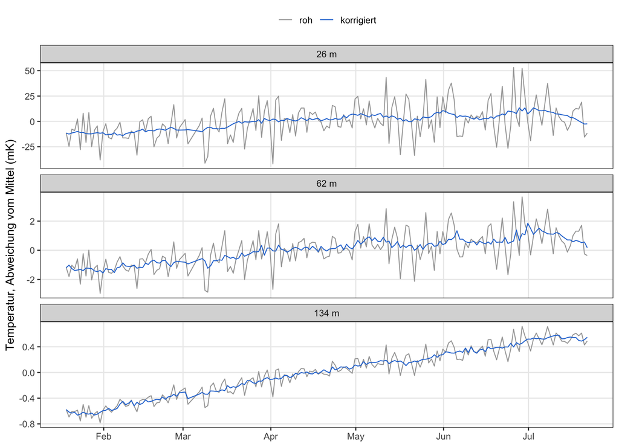

Figure 6

```r
zk <- c(26, 62, 134)
kd <- bind_rows(lapply(zk, function(z) { j <- which(round(dep4) == z)
  data.frame(t = h4$t[ok4], z = z, roh = k4$y[, j], korrigiert = k4$y[, j] - k4$corr[, j]) })) |>
  group_by(z) |> mutate(roh = roh - mean(korrigiert, na.rm = TRUE),
                        korrigiert = korrigiert - mean(korrigiert, na.rm = TRUE)) |> ungroup() |>
  pivot_longer(c(roh, korrigiert)) |>
  mutate(name = factor(name, c("roh", "korrigiert")), zl = factor(sprintf("%d m", z), sprintf("%d m", zk)))
ggplot(kd, aes(t, value, colour = name)) + geom_line(linewidth = 0.45) +
  facet_wrap(~ zl, ncol = 1, scales = "free_y") +
  scale_colour_manual(values = c(roh = "grey65", korrigiert = BLUE), name = NULL) +
  labs(x = NULL, y = "Temperatur, Abweichung vom Mittel (mK)") + th + theme(legend.position = "top")
```

Abbildung 6: head04, Rohdaten und korrigierte Reihe (Mittel NTC1/NTC2) in drei Tiefen.

- Die Tag-zu-Tag-Streuung sinkt bei head04 bei 26–50 m um den Faktor 8–16, bei 92–201 m von 0,08–0,16 auf 0,023–0,032 mK. Bei der Luftkette von head03 sinkt sie bei 21–50 m um den Faktor 7–21.
- Die Trends ändern sich um 3–7 % ihres Fehlers. Die Korrektur entfernt Schwankungen, keine Erwärmung; die kleine Verschiebung stammt aus dem mittleren dp/dt über den Messzeitraum.
- Der Trendfehler (AR(1)-korrigiert) sinkt bei head04 meist um 15–50 %, bei head03 um 32–74 %; bei head04 steigt er bei 40 m (+7 %) und 201 m (+57 %). Vor der Korrektur waren die Reste um den linearen Trend bei head04 von Tag zu Tag unkorreliert (Lag-1-Autokorrelation −0,06 bis +0,04 bei 16–158 m): die Bohrlochvariabilität dekorreliert innerhalb eines Tages. Danach bleibt ein langsamer Rest (Autokorrelation 0,6–0,9), der den Trendfehler bestimmt und durch die AR(1)-Korrektur stärker gewichtet wird. Bei 92–158 m hat er 0,04–0,05 mK Streuung, die Größe des NTC1−NTC2-Rauschens; sein über die Tiefen gemeinsamer Anteil (0,09 mK, Jahresgang ±0,06 mK) korreliert mit der Platinentemperatur (r = 0,58).
- Für `b40_inversion.qmd`: die dort angenommene Dekorrelationszeit von 30 Tagen für die Bohrlochvariabilität ist mit den Daten nicht vereinbar; gemessen ist höchstens ein Tag. Mit den korrigierten Reihen entfällt dieser Fehlerterm weitgehend.

## Offen

- Bei 21 und 32 m bleiben nach `b·F` 4,6 bzw. 1,2 mK (vorher 43 bzw. 14 mK). In B46 ist der Rest nahe dem Temperaturmaximum schief verteilt (Schiefe −1,2 bei 10–13 m, +1,2 bei 5 m), was auf Verschiebungen im Meterbereich deutet, bei denen der lineare Ansatz nicht mehr reicht.
- Welcher Prozess die 10–15 min bei B46 setzt, ist nicht geklärt; die Wärmeleitung zur Wand allein ergibt 20–50 s.
- Direkter Test: schnelle Daten aus B40 selbst. Die Hypothese sagt voraus, dass unterhalb von 92 m die Temperatur bei allen auflösbaren Perioden um 90° gegen den Druck verschoben ist (keine Hochpass-Ecke im Minutenbereich), oberhalb eine Ecke bei 10–15 min wie in B46. Vorher ist die Verzögerung von ~70 s zwischen p und T desselben Knotens zu klären (Abbildung 4).
- Ein Barometer mit 10-min-Werten in Kohnen würde die Rate unmittelbar vor 17:38 liefern; der Rest müsste damit kleiner werden.